# 민주화 이후 한국 재보궐 선거데이터 코드북 (국회의원 선거)

Coodbook for Re/By-Election of South Korea (General Elections)

Sanghoon Park

2022-6-19

# Data Descriptions

## 재보궐 선거 변수

**ELEC_DATE**

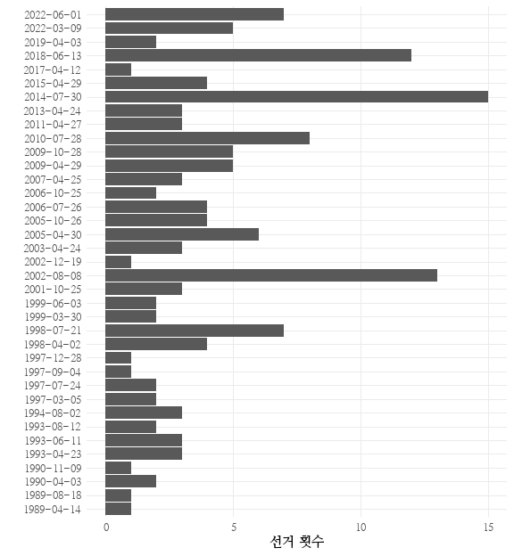

재보궐 선거의 추이

**ELEC_TYPE**

선거유형(CHR), 선출유형에 따른 분류 (현재는 국회의원만 코딩).

**CITY**

시도(CHR), 시도 구분.

**DISTRICT**

선거구(CHR), 선거구명.

**ELEC_POP**

선거인수(NUM), 총 유권자 수.

**ELEC_VOTER**

투표수(NUM), 총 투표인 수.

**ELEC_RESIGN**

기권자수(NUM) 총 유권자 수 - 총 투표인 수.

**ELEC_TURNOUT**

투표율(NUM) 총 투표인 수 / 총 유권자 수 * 100.

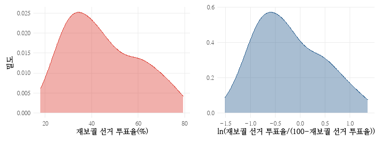

재보궐 선거 투표율 변수의 분포

**ELEC_REASON**

사유(FCT) 재보궐 시행 사유.

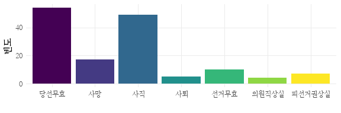

재보궐 선거 사유

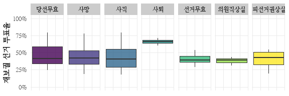

재보궐 시행 사유별 투표율

**ELEC_COMPETE**

재보궐경쟁률(NUM), 100 * (2위 득표자 득표율 / 해당 재보궐 선거에서 당선자 득표율).

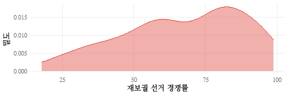

재보궐 선거 경쟁률의 분포

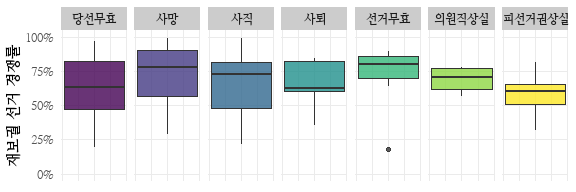

재보궐 시행 사유별 경쟁률

**ELEC_CANDINUM**

재보궐후보자수(NUM), 해당 재보궐 선거에 참여한 후보의 수.

**ELEC_EFFECTNUM**

재보궐 유효후보자수(NUM), 해당 재보궐 선거에 참여한 득표율 3% 이상의 유효후보의 수.

## 재보궐 당선자 변수

**ELEC_PARTY**

당선자당적(CHR) 재보궐선거 당선자의 당적.

**ELEC_ELECTED**

당선자명(CHR), 재보궐선거 당선자의 이름.

**ELEC_GENDER**

당선자 성별(CHR), 재보궐선거 당선자의 성별 (남/여).

**ELEC_SHARE**

당선자득표율(NUM), 재보궐 선거 당선자의 득표율.

**ELEC_NUMBER**

선수(NUM), 재보궐 선거 당선자의 당선 당시 선수 (초선/재선/3선 등).

## 재보궐 2위득표자 변수

**RIVAL_PARTY**

2위득표자당적(CHR), 재보궐 선거 2위 득표자의 당적.

**RIVAL_NAME**

2위득표자명(CHR), 재보궐 선거 2위 득표자의 이름.

**RIVAL_GENDER**

2위득표자성별(CHR), 재보궐선거 2위 득표자의 성별 (남/여).

**RIVAL_SHARE**

2위득표자득표율(NUM), 재보궐 선거 2위 득표자의 득표율.

## 재보궐 선거 직전 총선 변수

**PRE_POP**

직전총선선거인수(NUM), 해당 재보궐 선거 직전의 총선을 대상으로 선거통계시스템에서 인용한 총 선거인 수.

**PRE_VOTER**

직전총선투표인수(NUM), 해당 재보궐 선거 직전의 총선을 대상으로 선거통계시스템에서 인용한 총 투표인 수.

**PRE_RESIGN**

직전총선기권자수(NUM), 해당 재보궐 선거 직전의 총선을 대상으로 계산한 기권자 수: 선거인 수 - 총 투표인 수.

**PRE_TURNOUT**

직전총선투표율(NUM), 해당 재보궐 선거 직전의 총선을 대상으로 계산한 투표율: 총 투표인 수 / 총 유권자 수 * 100, 소수점 둘째자리로 반올림.

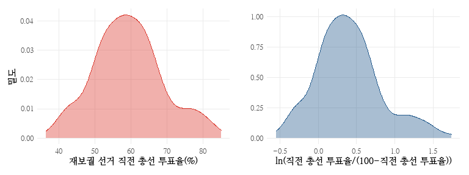

재보궐 선거 직전 총선 투표율 변수의 분포

**PRE_PARTY**

직전당선자당적(CHR), 해당 재보궐 선거 직전에 당선자의 당적.

**PRE_ELECTED**

직전당선자(CHR), 해당 재보궐 선거 직전에 당선된 자의 이름.

**PRE_SHARE**

직전총선당선득표율(NUM), 해당 재보궐 선거 직전의 총선에서 당선자의 득표율.

**PRE_RIVAL_SHARE**

직전총선2위득표율(NUM), 해당 재보궐 선거 직전의 총선에서 2위 득표자의 득표율.

**PRE_COMPETE**

직전선거경쟁률(NUM), 100 * (2위 득표자 득표율 / 해당 재보궐 선거 직전의 총선에서 당선자 득표율).

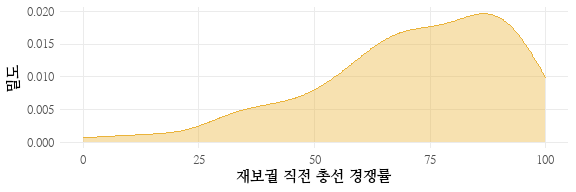

재보궐 직전 총선 경쟁률의 분포

**PRE_CANDINUM**

직전선거후보자수(NUM), 해당 재보궐 선거 직전의 총선에 참여한 후보의 수.

**PRE_EFFECTNUM**

직전선거 유효후보자수(NUM), 해당 재보궐 선거 직전의 총선에 참여한 득표율 3% 이상의 유효후보의 수.

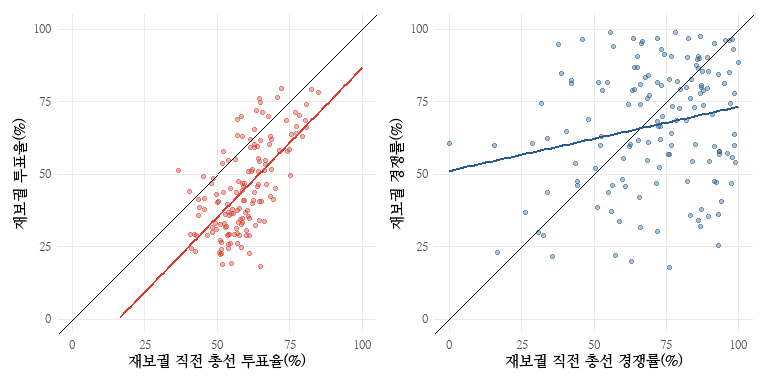

재보궐 선거 직전 총선 투표율과 재보궐 선거 투표율 간 관계

## 재보궐 선거 직후 총선 변수

**POST_POP**

직후총선선거인수(NUM), 해당 재보궐 선거 직후의 총선을 대상으로 선거통계시스템에서 인용한 총 선거인 수.

**POST_VOTER**

직후총선투표인수(NUM), 해당 재보궐 선거 직후의 총선을 대상으로 선거통계시스템에서 인용한 총 투표인 수.

**POST_RESIGN**

직후총선기권자수(NUM), 해당 재보궐 선거 직후의 총선을 대상으로 계산한 기권자 수: 선거인 수 - 총 투표인 수.

**POST_TURNOUT**

직후총선투표율(NUM), 해당 재보궐 선거 직후의 총선을 대상으로 계산한 투표율: 총 투표인 수 / 총 유권자 수 * 100, 소수점 둘째자리로 반올림.

[figure not shown]

재보궐 선거 직후 총선 투표율 변수의 분포

**POST_PARTY**

직후당선자당적(CHR), 해당 재보궐 선거 직후의 총선에서 당선자의 당적.

**POST_ELECTED**

직후당선자(CHR), 해당 재보궐 선거 직후의 총선에서 당선자의 이름.

**POST_SHARE**

직후총선당선득표율(NUM), 해당 재보궐 선거 직후의 총선에서 당선자의 득표율.

**POST_RIVAL_SHARE**

직후총선2위득표율(NUM), 해당 재보궐 선거 직후의 총선에서 2위 득표자의 득표율.

**POST_COMPETE**

직후총선경쟁률(NUM), 100 * (2위 득표자 득표율 / 해당 재보궐 선거 직후의 총선에서 당선자 득표율).

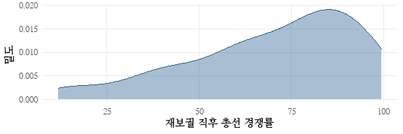

재보궐 직후 총선 경쟁률의 분포

**POST_CANDINUM**

직후선거후보자수(NUM), 해당 재보궐 선거 직후의 총선에 참여한 후보의 수.

**POST_EFFECTNUM**

직후선거 유효후보자수(NUM), 해당 재보궐 선거 직후의 총선에 참여한 득표율 3% 이상의 유효후보의 수.

## 기타 선거 관련 변수

**GENERAL_DATE**

인접총선일자(DATE), 재보궐 선거로부터 가장 가까운 미래 인접 총선의 일자.

**GENERAL_DIFF**

인접총선일자차이(NUM), 인접총선일자 - 선거일.

**GENERAL_TENURE**

의회임기_남은햇수(NUM), 재보궐 선거 당시 남은 의회 임기(햇수).

**PRESIDENT_DATE**

인접대선일자(DATE), 재보궐 선거로부터 가장 가까운 미래 인접 대선의 일자.

**PRESIDENT_DIFF**

인접대선일자차이(NUM), 인접대선일자 - 선거일.

**PRESIDENT_TENURE**

대통령임기_남은햇수(NUM), 재보궐 선거 당시 남은 대통령 임기(햇수).

**PRESIDENT_POSITIVE**

대통령_평가(긍정)(NUM), 재보궐선거가 실시된 시점 이전의 시기에서 가장 근접한 시점에 조사된 여론조사 전문기관인 한국갤럽이 조사한 주차별 대통령 국정운영 지지율(긍정).

**PRESIDENT_NEGATIVE**

대통령_평가(부정)(NUM), 재보궐선거가 실시된 시점 이전의 시기에서 가장 근접한 시점에 조사된 여론조사 전문기관인 한국갤럽이 조사한 주차별 대통령 국정운영 지지율(부정).

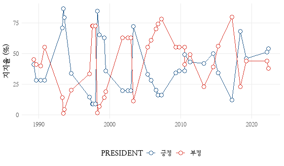

대통령 평가 (긍정/부정)

**REGIONALISM**

지역주의(FCT), 재보궐 선거가 실시된 지역을 기준으로 지역주의 코딩 (1 = PK (부울경) / 2 = TK (대구경북) / 3 = HN (호남) / 4 = 기타).

**RULINGPARTY**

여당(CHR), 재보궐 선거가 실시된 시점의 여당이름.

**RULINGAPPROVAL**

여당지지도(NUM), 재보궐 선거가 실시된 시점 이전의 시기에서 가장 근접한 시점에 조사된 여론조사 전문기관인 리서치앤리서치(R&R)가 조사한 여당지지율.

**PRE_ELEC_CANDI_DIFF**

직전재보궐후보자수차이(NUM), 재보궐 선거에 참여한 후보자 수 - 해당 재보궐 선거 직전의 총선에 참여한 후보의 수.

**POST_ELEC_CANDI_DIFF**

직후재보궐후보자수차이(NUM), 해당 재보궐 선거 직후의 총선에 참여한 후보의 수 - 재보궐 선거에 참여한 후보자 수.

**PRE_ELEC_SHIFT**

재보궐전교체(NUM), 재보궐 이전 총선의 당선자로부터 재보궐 선거 당선자의 당적이 교체된 경우 (이항변수; 1, 0).

**POST_ELEC_SHIFT**

재보궐이후교체(NUM), 재보궐 선거 당선자로부터 재보궐 이전 총선의 당선자의 당적이 교체된 경우 (이항변수; 1, 0).

**PRE_ELEC_COMPETE_DIFF**

직전보궐경쟁률차이(NUM), 재보궐경쟁률 - 직전선거경쟁률.

**POST_ELEC_COMPETE_DIFF**

직후보궐경쟁률차이(NUM), 직후선거경쟁률 - 재보궐경쟁률.

**PRE_ELEC_SHIFT2**

의석교체(FCT), 여당, 직전당선자당적과 당선자당적 변수를 바탕으로 1 = 여당 $\rightarrow$ 여당 / 2 = 여당 $\rightarrow$ 야당 / 3 = 야당 $\rightarrow$ 여당 / 4 = 야당 $\rightarrow$ 야당.

**ELEC_RULING**

여당유리지역주의(FCT), 선거 당시 여당을 지지하는 지역주의에 선거구가 위치하고 있으면 1 아니면 0.

**ELEC_OPPOSITION**

야당유리지역주의(FCT), 선거 당시 야당을 지지하는 지역주의에 선거구가 위치하고 있으면 1 아니면 0.

**PREVOTE**

사전투표제 도입 여부(NUM), 사전투표제도가 도입된 2013년도 상반기 재·보궐선거 이후 선거일 경우 1, 아니면 0.

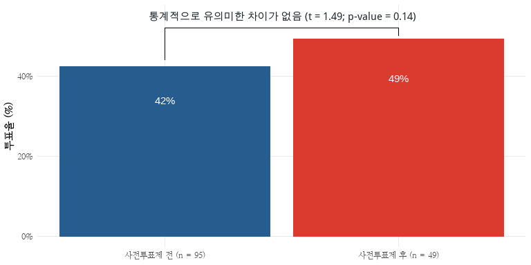

사전투표제도 도입 전후 재보궐선거 투표율 비교(평균)

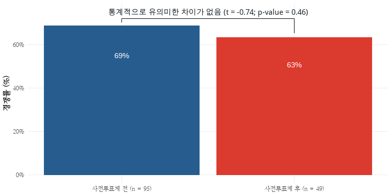

사전투표제도 도입 전후 재보궐선거 경쟁률 비교(평균)

# APPENDIX

## 재보궐 선거 지역구에 대한 간략한 정보

재보궐선거 지역구 및 재보궐 사유에 대한 정보

| 재보궐 선거일 | 시도 | 지역구 | 재보궐 사유 | 투표율 |
| --- | --- | --- | --- | --- |
| 1989-04-14 | 강원도 | 동해시 | 당선무효 | 79.1 |
| 1989-08-18 | 서울시 | 영등포을 | 당선무효 | 69.8 |
| 1990-04-03 | 대구시 | 서구갑 | 사퇴 | 63.9 |
| 1990-04-03 | 충청북도 | 진천음성군 | 사망 | 78.2 |
| 1990-11-09 | 전라남도 | 영광함평군 | 당선무효 | 70.2 |
| 1993-04-23 | 부산시 | 동래구갑 | 사직 | 40.4 |
| 1993-04-23 | 부산시 | 사하구 | 당선무효 | 42.1 |
| 1993-04-23 | 경기도 | 광명시 | 사망 | 41.2 |
| 1993-06-11 | 강원도 | 명주양양군 | 사퇴 | 68.5 |
| 1993-06-11 | 강원도 | 철원화천군 | 사퇴 | 66.0 |
| 1993-06-11 | 경상북도 | 예천군 | 사퇴 | 71.3 |
| 1993-08-12 | 대구시 | 동구을 | 사퇴 | 60.2 |
| 1993-08-12 | 강원도 | 춘천시 | 사망 | 58.5 |
| 1994-08-02 | 대구시 | 수성갑 | 당선무효 | 46.3 |
| 1994-08-02 | 강원도 | 영월평창군 | 사망 | 63.1 |
| 1994-08-02 | 경상북도 | 경주시 | 사망 | 49.7 |
| 1997-03-05 | 인천시 | 서구 | 사망 | 37.3 |
| 1997-03-05 | 경기도 | 수원시장안구 | 사망 | 32.7 |
| 1997-07-24 | 경상북도 | 포항시북구 | 당선무효 | 63.1 |
| 1997-07-24 | 충청남도 | 예산군 | 당선무효 | 68.5 |
| 1997-09-04 | 경기도 | 안양시만안구 | 사망 | 33.1 |
| 1997-12-28 | 광주시 | 동구 | 사망 | NA |
| 1998-04-02 | 부산시 | 서구 | 당선무효 | 45.7 |
| 1998-04-02 | 대구시 | 달성군 | 사직 | 59.4 |
| 1998-04-02 | 경상북도 | 문경시예천군 | 당선무효 | 66.3 |
| 1998-04-02 | 경상북도 | 의성군 | 당선무효 | 73.9 |
| 1998-07-21 | 서울시 | 종로구 | 사직 | 33.7 |
| 1998-07-21 | 서울시 | 서초구갑 | 사직 | 37.6 |
| 1998-07-21 | 부산시 | 해운대구기장군을 | 사직 | 58.3 |
| 1998-07-21 | 대구시 | 북구갑 | 사직 | 39.8 |

[output cut: 116 more lines]

## 주요 변수의 기술통계

주요 변수의 기술통계

| 변수 | 관측치 | 평균 | 표준편차 | 최소값 | 최대값 |
| --- | --- | --- | --- | --- | --- |
| ELEC_RESIGN | 145 | 89671.41 | 42138.62 | 11977.00 | 203142.00 |
| ELEC_TURNOUT | 145 | 44.71 | 15.58 | 18.12 | 79.47 |
| ELEC_COMPETE | 145 | 66.86 | 21.16 | 17.84 | 98.82 |
| PRE_RESIGN | 146 | 63624.24 | 26608.87 | 10012.00 | 128117.00 |
| PRE_TURNOUT | 146 | 59.37 | 9.68 | 36.52 | 85.06 |
| PRE_COMPETE | 146 | 70.94 | 21.09 | 0.00 | 99.98 |
| POST_RESIGN | 116 | 62820.69 | 28879.78 | 0.00 | 125886.00 |
| POST_TURNOUT | 107 | 57.41 | 8.61 | 37.71 | 80.58 |
| POST_COMPETE | 107 | 69.61 | 22.66 | 11.86 | 99.44 |